# Отчет по лабораторной работе №9

Настройка POP3/IMAP сервера

Виноградова М.А

Российский университет дружбы народов, Москва, Россия

24 октября 2026

# Информация

## Докладчик

- Виноградова Мария Андреевна
- студентка НПИбд-02-24
- номер студ. билета 1132240691
- Российский университет дружбы народов
- 1132240691@rudn.ru
- https://github.com/mavinogradova/study_2026-2027

# Цель работы

Приобретение практических навыков по установке и простейшему конфигурированию POP3/IMAP-сервера.

# Задание

1. Установите на виртуальной машине server Dovecot и Telnet для дальнейшей проверки корректности работы почтового сервера (см. раздел 9.4.1).
2. Настройте Dovecot (см. раздел 9.4.2).
3. Установите на виртуальной машине client программу для чтения почты Evolution и настройте её для манипуляций с почтой вашего пользователя. Проверьте корректность работы почтового сервера как с виртуальной машины server, так и с виртуальной машины client (см. раздел 9.4.3).
4. Измените скрипт для Vagrant, фиксирующий действия по установке и настройке Postfix и Dovecot во внутреннем окружении виртуальной машины server, создайте скрипт для Vagrant, фиксирующий действия по установке Evolution во внутреннем окружении виртуальной машины client. Соответствующим образом внесите изменения в Vagrantfile (см. раздел 9.4.4).

# Выполнение лабораторной работы

## Установка Dovecot. Вход на server и установка пакетов

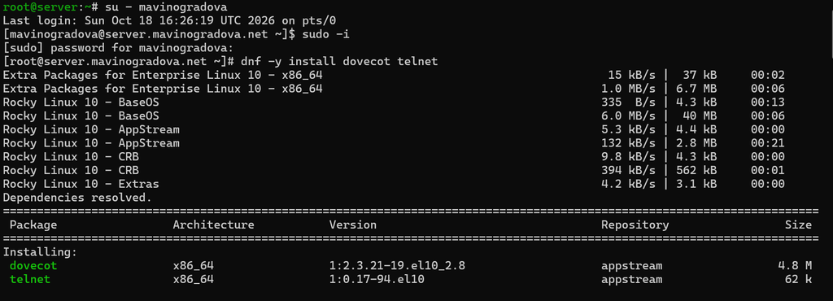

Вход на виртуальную машину server, переход в режим суперпользователя и установка пакетов dovecot и telnet

## Настройка Dovecot. dovecot.conf

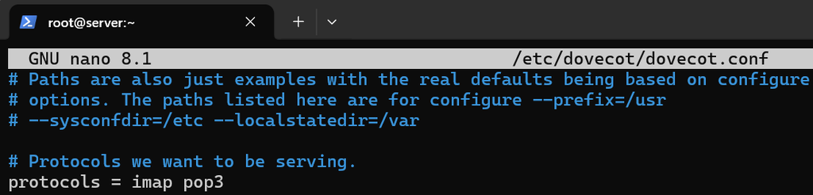

Настройка списка протоколов в файле dovecot.conf

## Настройка Dovecot. 10-auth.conf

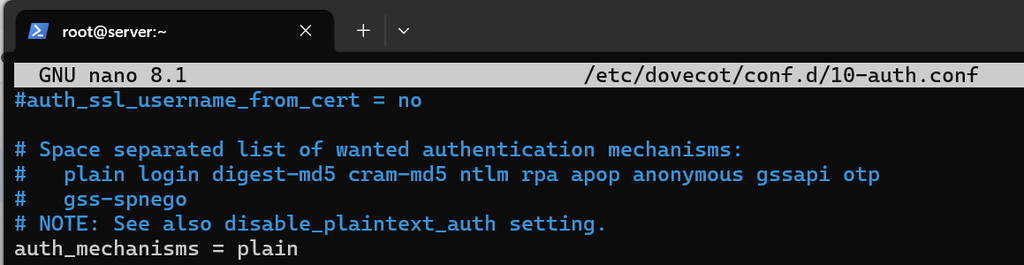

Проверка метода аутентификации в файле 10-auth.conf

## Настройка Dovecot. auth-system.conf.ext (passdb)

[figure not shown]

Проверка настройки passdb в файле auth-system.conf.ext

## Настройка Dovecot. auth-system.conf.ext (userdb)

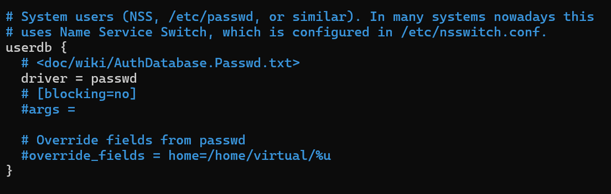

Проверка настройки userdb в файле auth-system.conf.ext

## Настройка Dovecot. 10-mail.conf

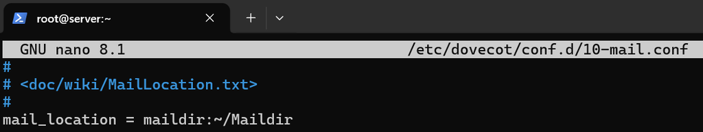

Настройка местоположения почтовых ящиков в файле 10-mail.conf

## Настройка Dovecot. Postfix и firewall

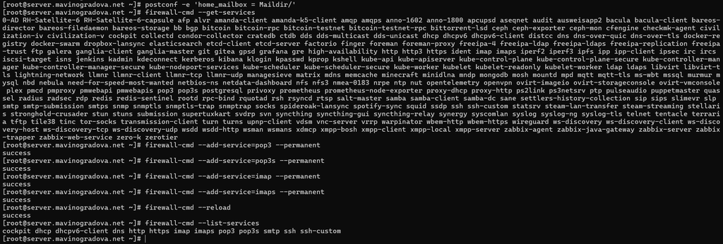

Настройка Postfix и межсетевого экрана для POP3/IMAP

## Настройка Dovecot. SELinux и перезапуск служб

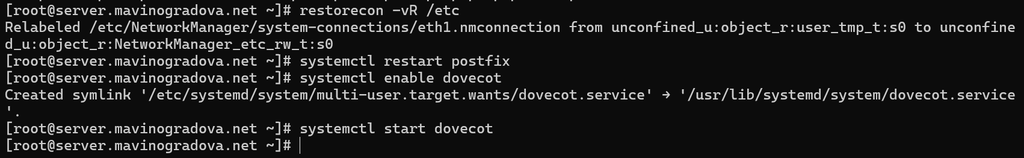

Восстановление контекста SELinux, перезапуск Postfix и запуск Dovecot

## Проверка работы. Мониторинг логов

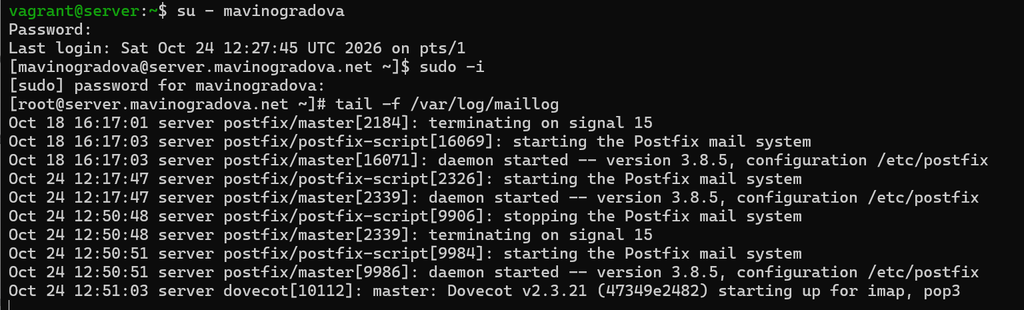

Запуск мониторинга логов почтовой службы

## Проверка работы. Просмотр писем (mail)

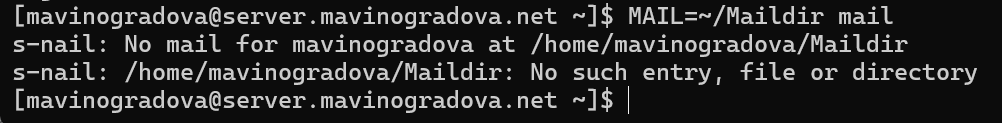

Просмотр имеющихся писем утилитой mail

## Проверка работы. Просмотр mailbox (doveadm)

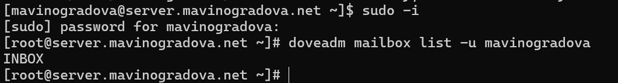

Просмотр списка почтовых ящиков пользователя через doveadm

## Проверка работы. Вход на client

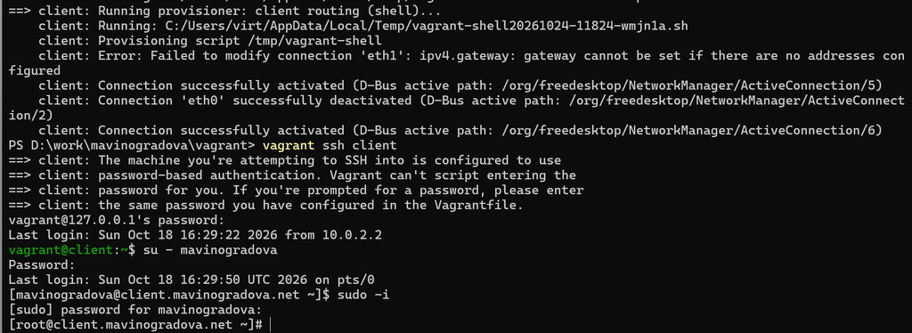

Вход на виртуальную машину client и переход в режим суперпользователя

## Проверка работы. Установка Evolution

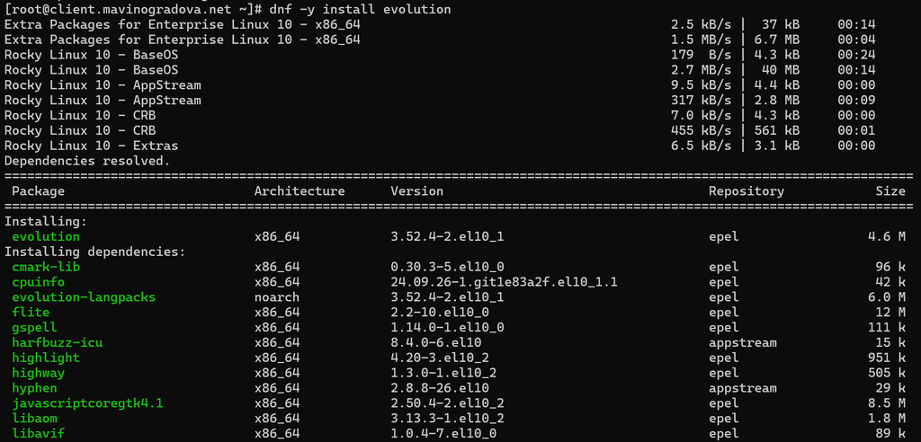

Установка почтового клиента Evolution

## Проверка работы. Запуск Evolution

[figure not shown]

Графическое окружение виртуальной машины client с установленным Evolution

## Настройка Evolution. Identity

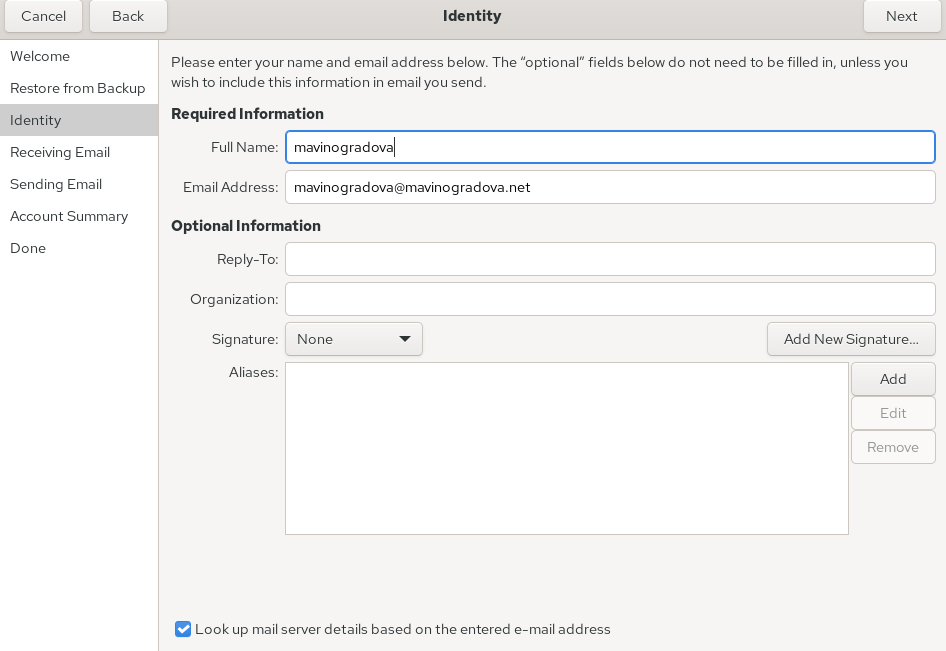

Настройка учетной записи в Evolution (вкладка Identity)

## Настройка Evolution. IMAP

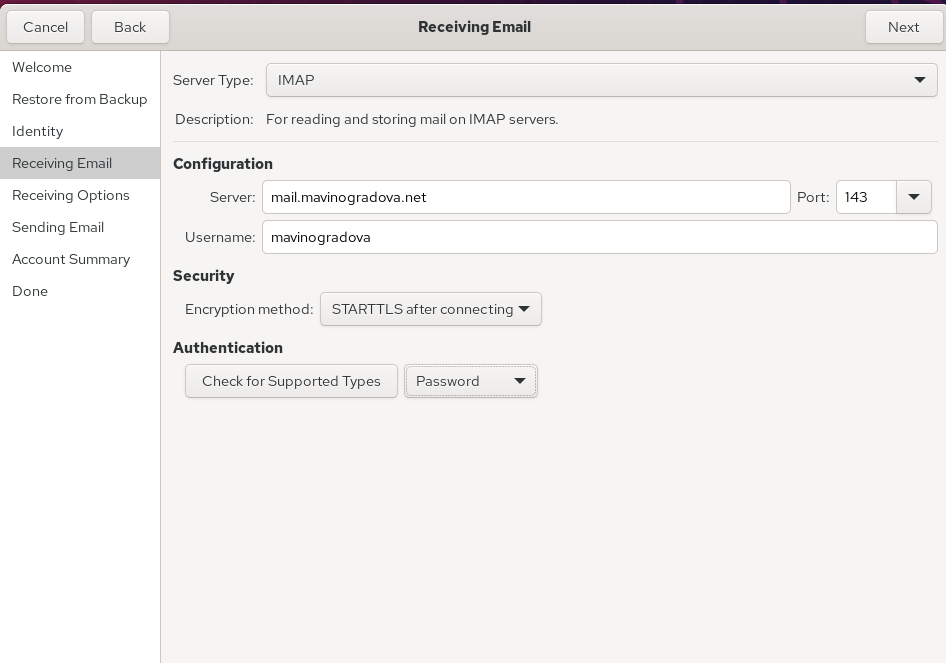

Настройка получения почты (IMAP) в Evolution

## Настройка Evolution. SMTP

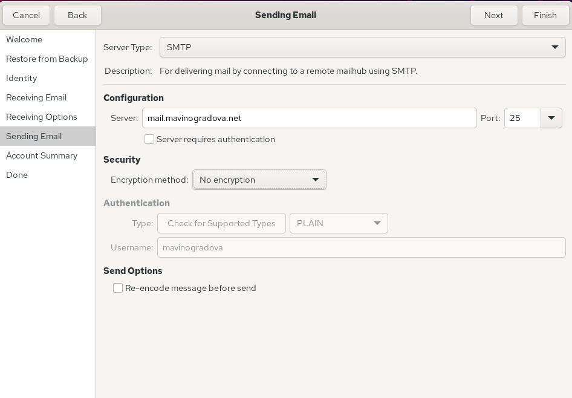

Настройка отправки почты (SMTP) в Evolution

## Настройка Evolution. Главное окно

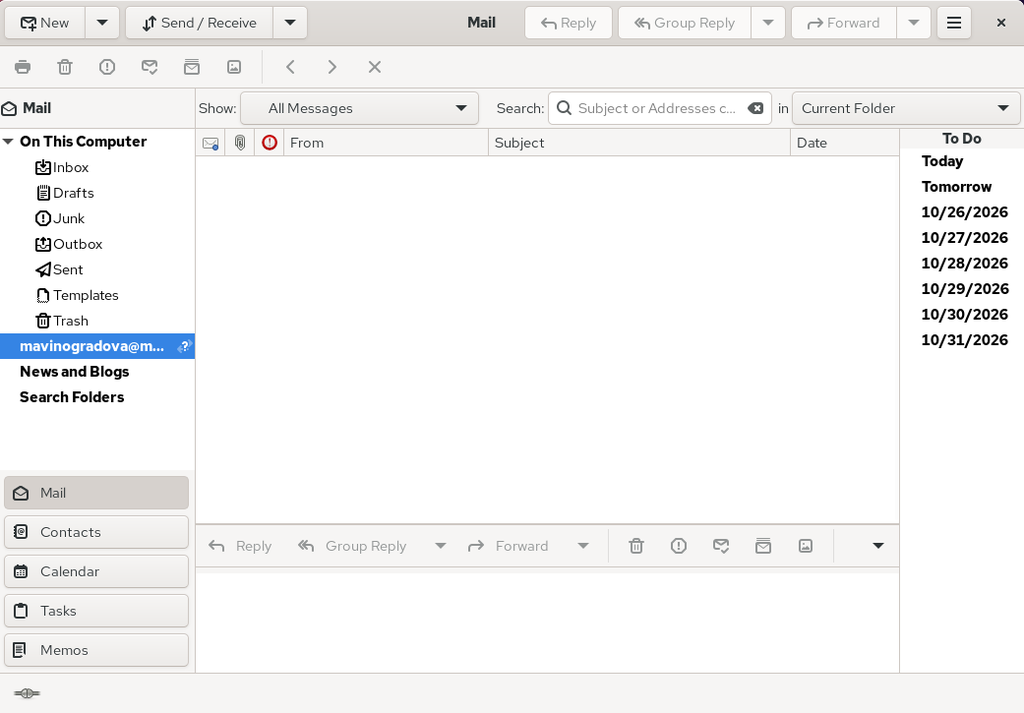

Главное окно Evolution после настройки учетной записи

## Отправка писем. Test 1

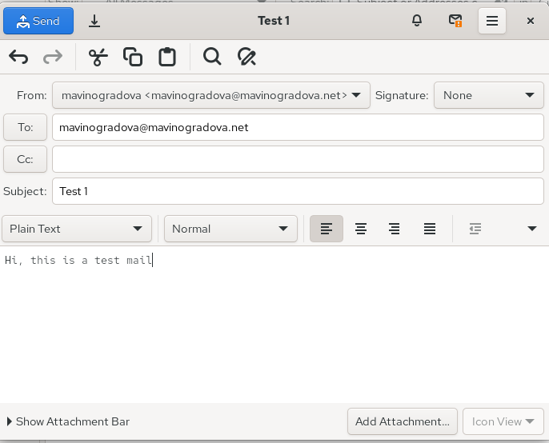

Создание первого тестового письма

## Отправка писем. Test 3

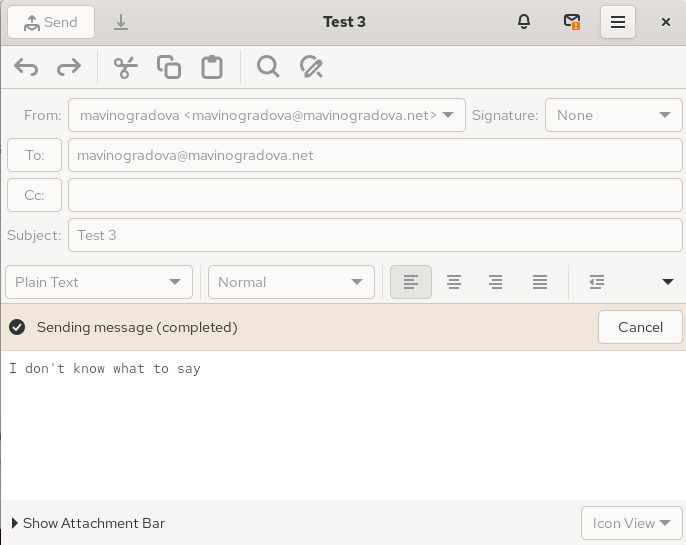

Создание и отправка третьего тестового письма

## Отправка писем. Test 4

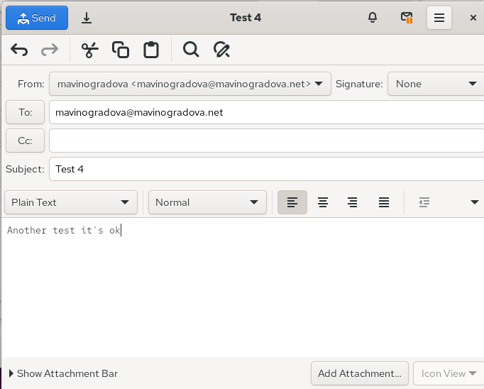

Создание четвертого тестового письма

## Отправка писем. Finish Test

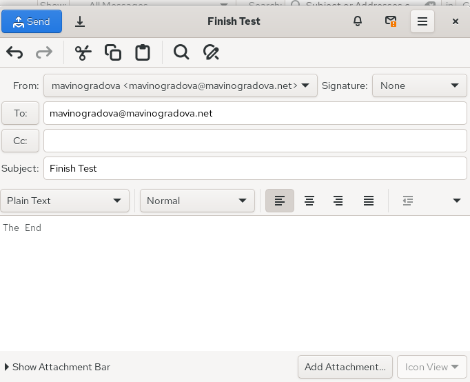

Создание финального тестового письма

## Отправка писем. Сертификат

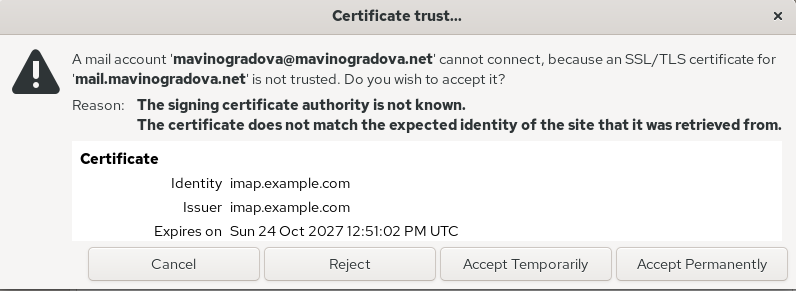

Предупреждение о небезопасном SSL/TLS сертификате

## Отправка писем. Пароль

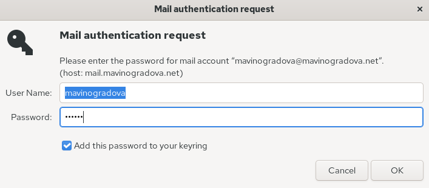

Ввод пароля для учетной записи

## Результат. Папка Sent

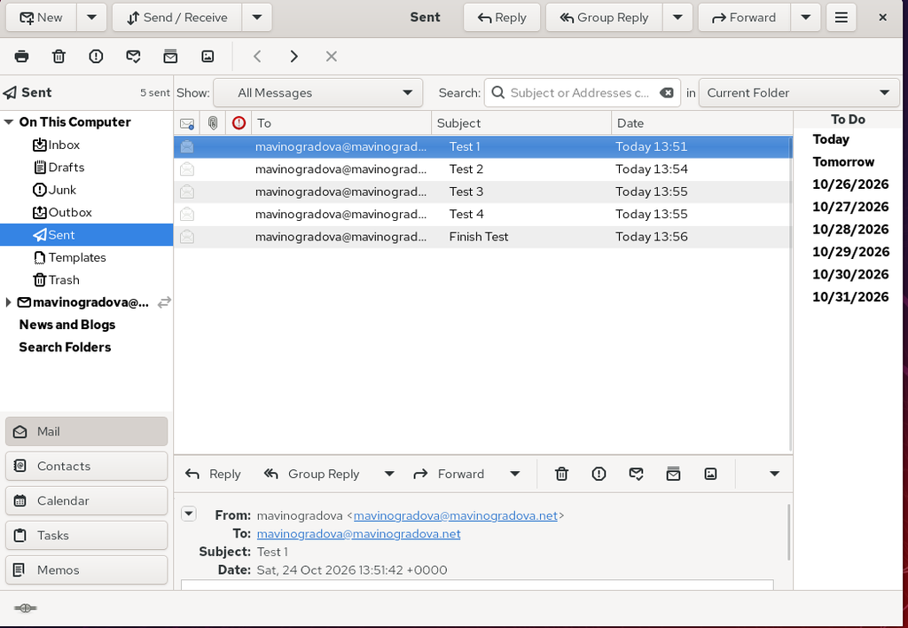

Папка Sent с отправленными письмами

## Результат. Папка Inbox

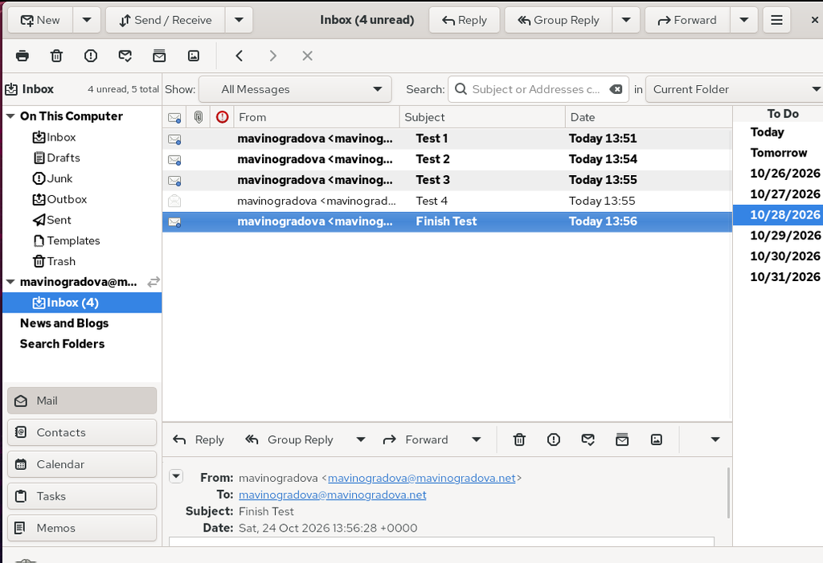

Папка Inbox с полученными письмами

## Результат. Проверка статуса doveadm

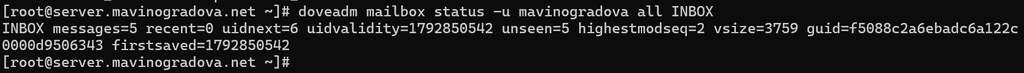

Проверка статуса почтового ящика через doveadm

## Результат. Мониторинг логов maillog

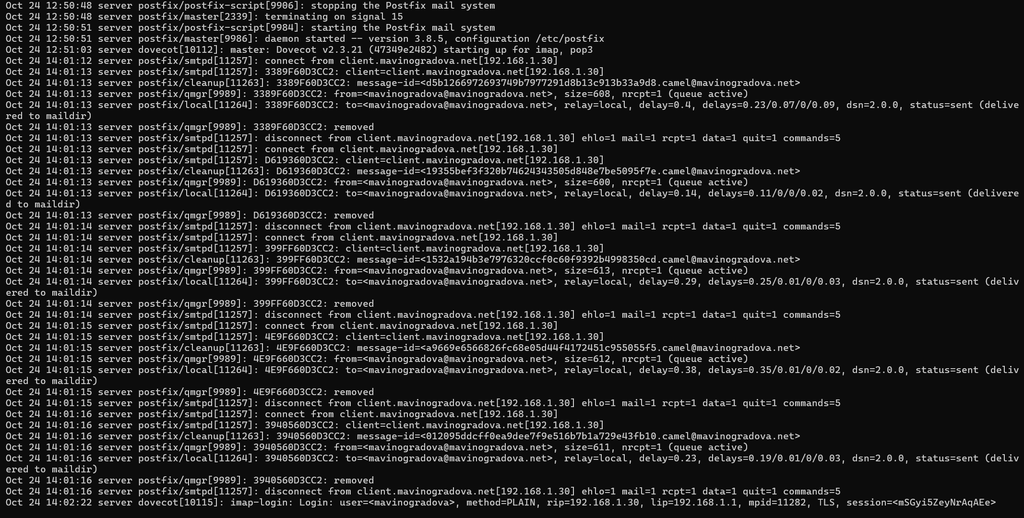

Мониторинг логов maillog во время отправки и получения писем

## Проверка через Telnet (POP3)

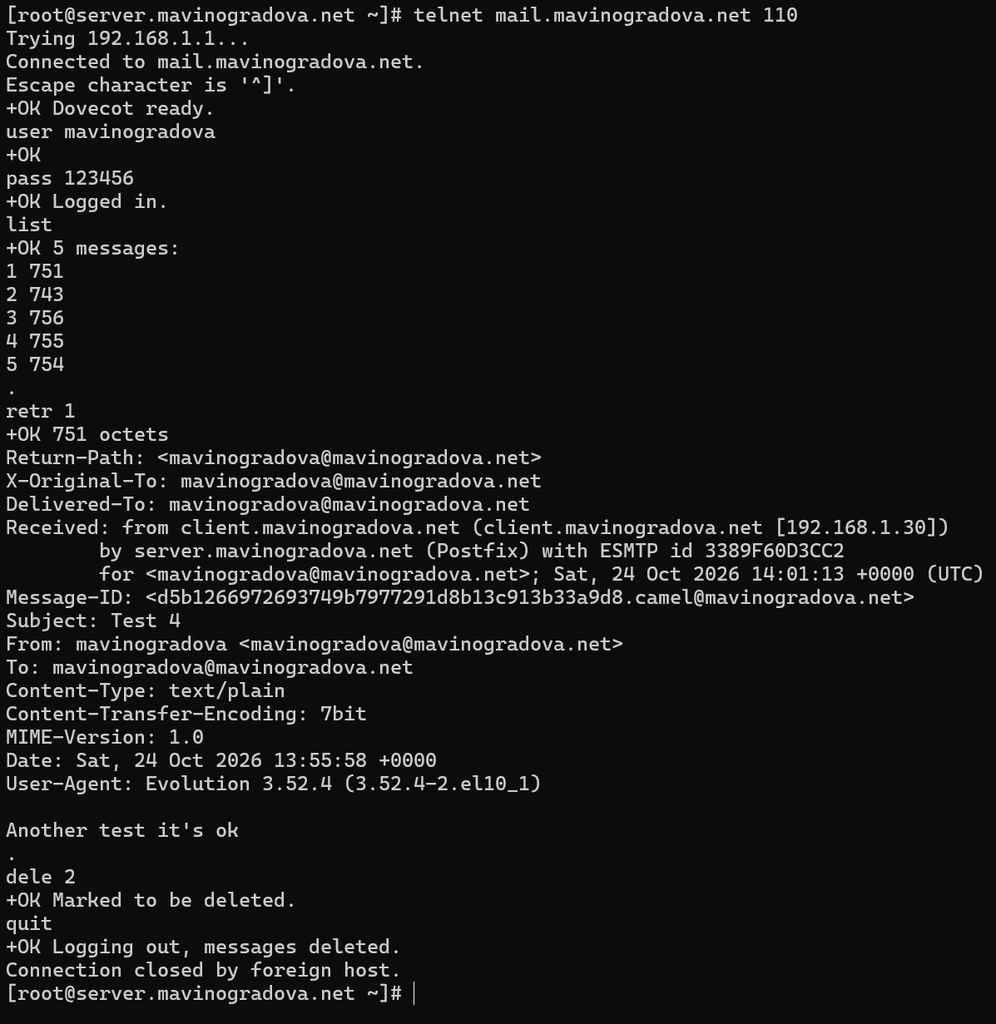

Проверка работы POP3 через Telnet

## Окружение ВМ. Копирование конфигов

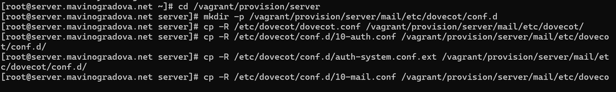

Копирование конфигурационных файлов Dovecot в каталог провижининга

## Окружение ВМ. mail.sh на сервере

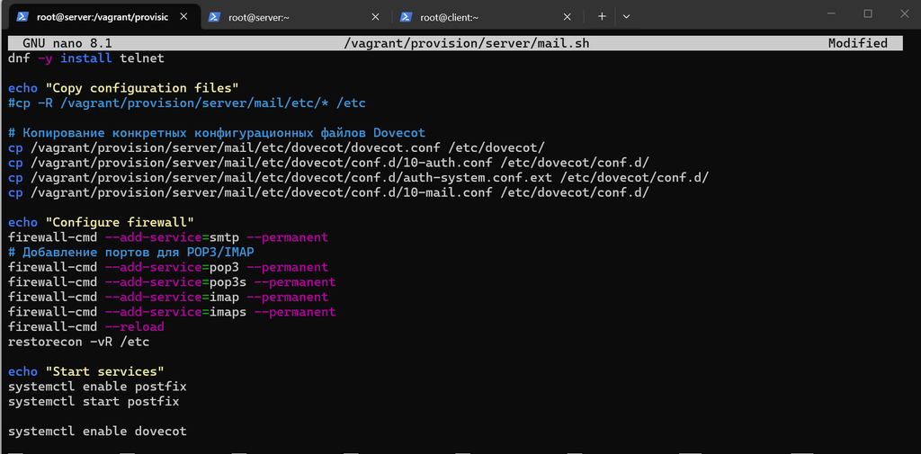

Редактирование скрипта provision/server/mail.sh

## Окружение ВМ. mail.sh на клиенте

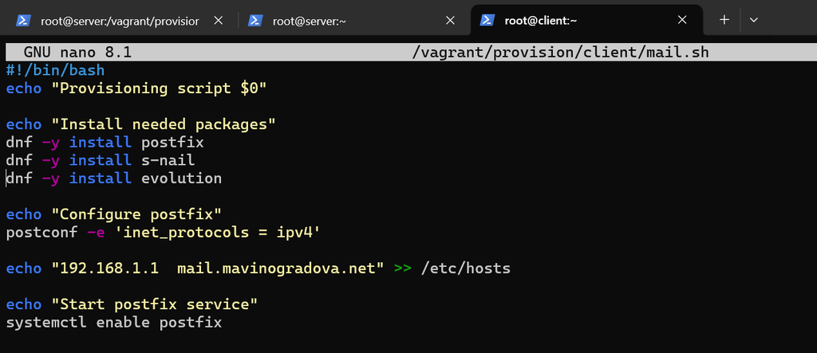

Редактирование скрипта provision/client/mail.sh

# Выводы

В ходе лабораторной работы были приобретены практические навыки по установке и простейшему конфигурированию POP3/IMAP-сервера. Был установлен и настроен Dovecot на сервере, настроены протоколы IMAP и POP3, методы аутентификации и расположение почтовых ящиков (формат Maildir). Проверена работа почтового сервера с помощью утилиты Evolution на клиентской машине, а также с использованием протокола Telnet. Автоматизированы действия по установке и настройке Postfix и Dovecot с помощью скриптов провижининга для Vagrant, а также установка клиента Evolution.

# Список литературы

1. Методические указания к лабораторной работе № 9 «Настройка POP3/IMAP сервера».
2. Dovecot Documentation. — URL: https://dovecot.org/documentation (visited on 09/13/2021).
3. Postfix Documentation. — URL: http://www.postfix.org/documentation.html (visited on 09/13/2021).